# Bioaerosol Infection Risk Assessment Report

## 4.2 Annual Infection Risk

```
## **Summary statistics**
##      Min.   1st Qu.    Median      Mean   3rd Qu.      Max.
## 6.100e-07 5.580e-05 1.613e-04 5.623e-04 4.782e-04 4.029e-02
```

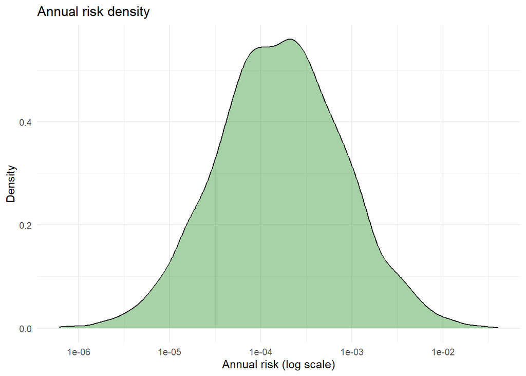

# 5. Sensitivity Analysis

## 5.1 Spearman Rank Correlation

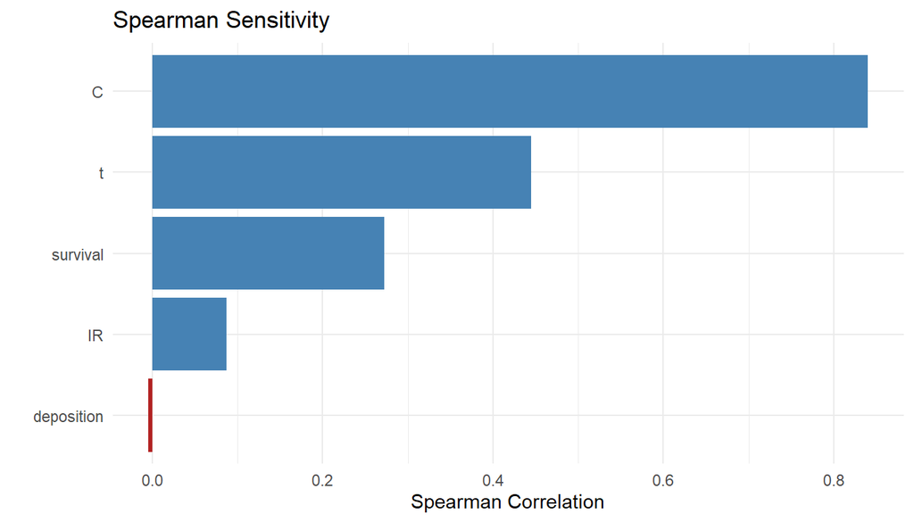

## 5.2 PRCC (Partial Rank Correlation Coefficient)

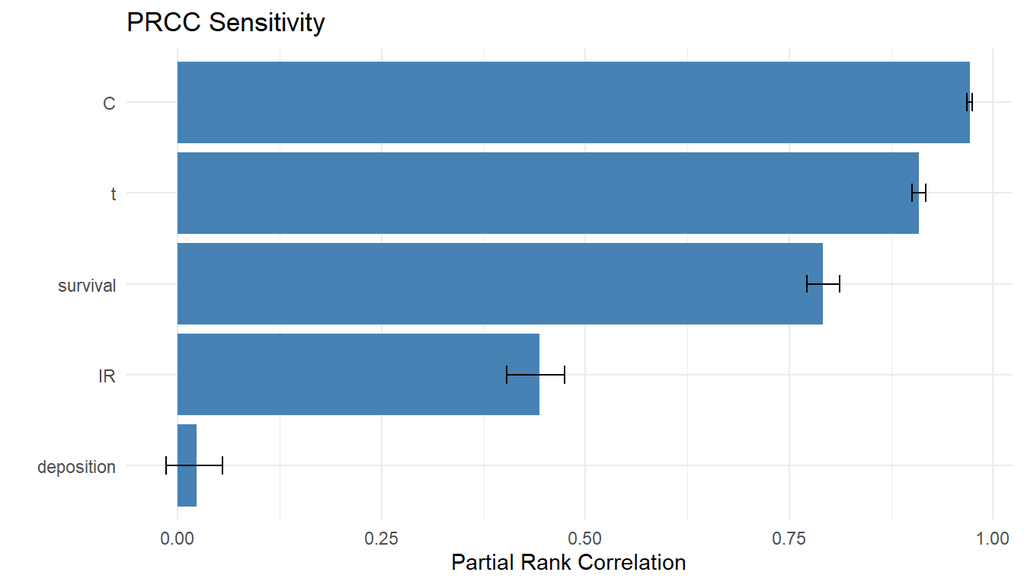

## 5.3 Morris Elementary Effects

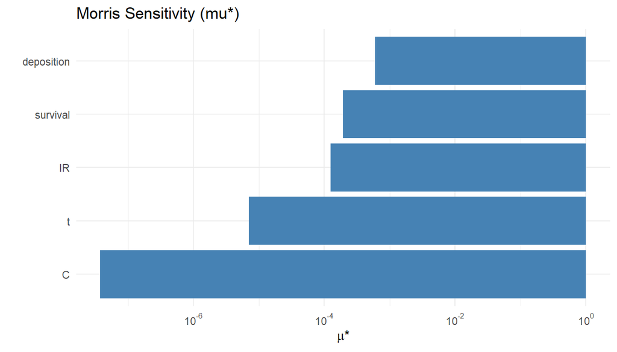

## 5.4 Sobol’ Variance Decomposition

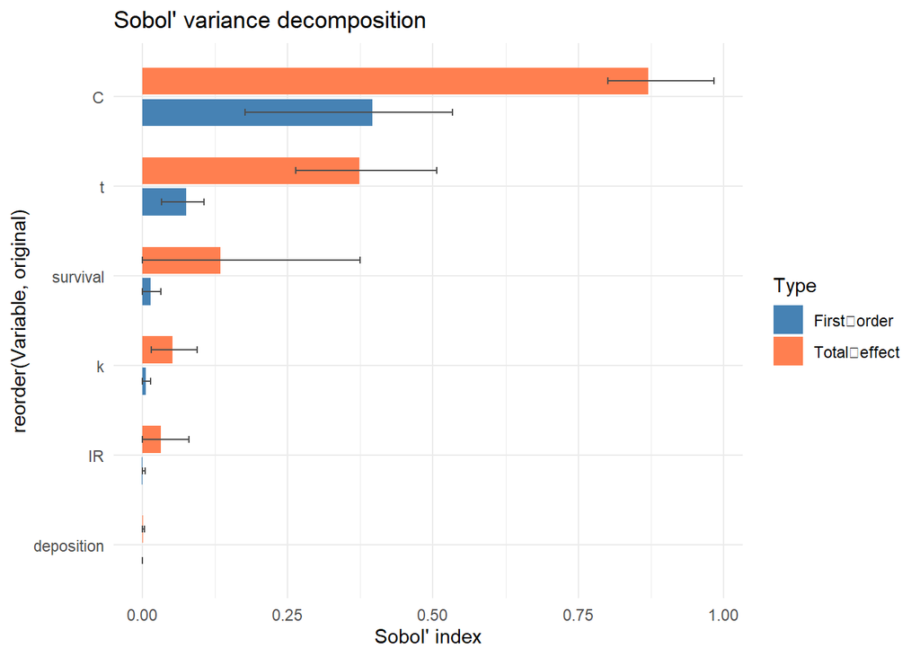